# Heart Failure Prediction

## Problem Statement :

With a plethora of medical data available and the rise of Data Science, a host of startups are taking up the challenge of attempting to create indicators for the forseen diseases that might be contracted! Cardiovascular diseases (CVDs) are the number 1 cause of death globally, taking an estimated 17.9 million lives each year, which accounts for 31% of all deaths worldwide. Heart failure is a common event caused by CVDs. People with cardiovascular disease or who are at high cardiovascular risk (due to the presence of one or more risk factors such as hypertension, diabetes, hyperlipidaemia or already established disease) need early detection and management wherein a machine learning model can be of great help. In this way, we try to solve automate another problem that occurs in the nature with a view to counter it and focus on to the next problem with the help of AI techniques!

Aim : To classify / predict whether a patient is prone to heart failure depending on multiple attributes. It is a binary classification with multiple numerical and categorical features.

Age : age of the patient [years] Sex : sex of the patient [M: Male, F: Female] ChestPainType : chest pain type [TA: Typical Angina, ATA: Atypical Angina, NAP: Non-Anginal Pain, ASY: Asymptomatic] RestingBP : resting blood pressure [mm Hg] Cholesterol : serum cholesterol [mm/dl] FastingBS : fasting blood sugar [1: if FastingBS > 120 mg/dl, 0: otherwise] RestingECG : resting electrocardiogram results [Normal: Normal, ST: having ST-T wave abnormality (T wave inversions and/or ST elevation or depression of > 0.05 mV), LVH: showing probable or definite left ventricular hypertrophy by Estes' criteria] MaxHR : maximum heart rate achieved [Numeric value between 60 and 202] ExerciseAngina : exercise-induced angina [Y: Yes, N: No] Oldpeak : oldpeak = ST [Numeric value measured in depression] ST_Slope : the slope of the peak exercise ST segment [Up: upsloping, Flat: flat, Down: downsloping]

# HeartDisease : output class [1: heart disease, 0: Normal]

```python
# =============================================================================================

#  COMPREHENSIVE LIBRARY IMPORTS FOR HEART DISEASE ANALYSIS

# ========================================================================================
import numpy as np
import pandas as pd
import matplotlib.pyplot as plt
import seaborn as sns
from sklearn.neighbors import KNeighborsClassifier
from sklearn.preprocessing import StandardScaler, LabelEncoder ,OneHotEncoder
from sklearn.linear_model import LogisticRegression
from sklearn.model_selection import GridSearchCV
from sklearn.svm import SVC
from sklearn.naive_bayes import GaussianNB
from sklearn.neighbors import KNeighborsClassifier
from sklearn.tree import DecisionTreeClassifier
from sklearn.ensemble import RandomForestClassifier, GradientBoostingClassifier,AdaBoostClassifier
from xgboost import XGBClassifier
from sklearn.metrics import (accuracy_score, precision_score, recall_score, f1_score, roc_auc_score, confusion_matrix, classification_report, roc_curve)
from sklearn.metrics import make_scorer
from sklearn.naive_bayes import GaussianNB
print("\n\n ============= ALL LIBRARIES IMPORTED SUCCESSFULLY!==============\n\n")
```

```
 ============= ALL LIBRARIES IMPORTED SUCCESSFULLY!==============
```

# 1. LOADING AND INSPECTING HEART FAILURE DATASET

```python
# Loading the dataset
data = pd.read_csv('mergecvd.csv')

print("\n Dataset Loaded Successfully!")
print(f'\n Dataset Shape : {data.shape[0]} rows * {data.shape[1]} columns ')

print("\n FIRST 10 ROWS OF THE DATASET")
data.head(10)
```

```
 Dataset Loaded Successfully!

 Dataset Shape : 1918 rows * 12 columns

 FIRST 10 ROWS OF THE DATASET
```

|  | Age | Sex | ChestPainType | RestingBP | Cholesterol | FastingBS | RestingECG | MaxHR | ExerciseAngina | Oldpeak | ST_Slope | HeartDisease |
| --- | --- | --- | --- | --- | --- | --- | --- | --- | --- | --- | --- | --- |
| 0 | 40 | M | ATA | 140 | 289 | 0 | Normal | 172 | N | 0.0 | Up | 0 |
| 1 | 49 | F | NAP | 160 | 180 | 0 | Normal | 156 | N | 1.0 | Flat | 1 |
| 2 | 37 | M | ATA | 130 | 283 | 0 | ST | 98 | N | 0.0 | Up | 0 |
| 3 | 48 | F | ASY | 138 | 214 | 0 | Normal | 108 | Y | 1.5 | Flat | 1 |
| 4 | 54 | M | NAP | 150 | 195 | 0 | Normal | 122 | N | 0.0 | Up | 0 |
| 5 | 39 | M | NAP | 120 | 339 | 0 | Normal | 170 | N | 0.0 | Up | 0 |
| 6 | 45 | F | ATA | 130 | 237 | 0 | Normal | 170 | N | 0.0 | Up | 0 |
| 7 | 54 | M | ATA | 110 | 208 | 0 | Normal | 142 | N | 0.0 | Up | 0 |
| 8 | 37 | M | ASY | 140 | 207 | 0 | Normal | 130 | Y | 1.5 | Flat | 1 |
| 9 | 48 | F | ATA | 120 | 284 | 0 | Normal | 120 | N | 0.0 | Up | 0 |

```python
print("\nDATASET INFORMATION\n")
data.info()
```

```
DATASET INFORMATION

<class 'pandas.core.frame.DataFrame'>
RangeIndex: 1918 entries, 0 to 1917
Data columns (total 12 columns):
 #   Column          Non-Null Count  Dtype
---  ------          --------------  -----
 0   Age             1918 non-null   int64
 1   Sex             1918 non-null   object
 2   ChestPainType   1918 non-null   object
 3   RestingBP       1918 non-null   int64
 4   Cholesterol     1918 non-null   int64
 5   FastingBS       1918 non-null   int64
 6   RestingECG      1918 non-null   object
 7   MaxHR           1918 non-null   int64
 8   ExerciseAngina  1918 non-null   object
 9   Oldpeak         1918 non-null   float64
 10  ST_Slope        1738 non-null   object
 11  HeartDisease    1918 non-null   int64
dtypes: float64(1), int64(6), object(5)
memory usage: 179.9+ KB
```

```python
print("\nSTATISTICAL SUMMARY\n")
data.describe()
```

```
STATISTICAL SUMMARY
```

|  | Age | RestingBP | Cholesterol | FastingBS | MaxHR | Oldpeak | HeartDisease |
| --- | --- | --- | --- | --- | --- | --- | --- |
| count | 1918.000000 | 1918.000000 | 1918.000000 | 1918.000000 | 1918.000000 | 1918.000000 | 1918.000000 |
| mean | 51.285193 | 142.485401 | 257.531283 | 0.265902 | 141.328467 | 1.836444 | 0.567258 |
| std | 14.609167 | 26.932915 | 134.286677 | 0.441928 | 30.627152 | 1.707201 | 0.495585 |
| min | 20.000000 | 0.000000 | 0.000000 | 0.000000 | 60.000000 | -2.600000 | 0.000000 |
| 25% | 41.000000 | 124.000000 | 197.250000 | 0.000000 | 120.000000 | 0.300000 | 0.000000 |
| 50% | 53.000000 | 138.000000 | 256.000000 | 0.000000 | 141.000000 | 1.500000 | 1.000000 |
| 75% | 62.000000 | 160.000000 | 337.000000 | 1.000000 | 165.000000 | 2.900000 | 1.000000 |
| max | 80.000000 | 200.000000 | 603.000000 | 1.000000 | 202.000000 | 6.200000 | 1.000000 |

## Cholestrol

- average = 257.5 -> After analysis we can say that average cholesterol slightly above normal (<200 mg/dL).

## Fasting BS

- most of the people having not suffereing from FastingBS . around 26% of patients have high blood sugar.
- May be quarter of patients may be diabetic another risk factor of heart disease.

## MaxHR(Maximum Heart Rate Achieved)

- Aprroximately normal distributions ; no outliers .

## Oldpeak (ST depression Induced by Exercise)

- 75 percent of population have mild-to-moderate ST depression.

## HeartDisease(Target Variable)

- Dataset is balanced.

```python
print("\n=============================================================================\n")
print("DATASET COLUMN NAMES")
print("\n=============================================================================\n")

print(data.columns)
```

```
=============================================================================

DATASET COLUMN NAMES

=============================================================================

Index(['Age', 'Sex', 'ChestPainType', 'RestingBP', 'Cholesterol', 'FastingBS',
       'RestingECG', 'MaxHR', 'ExerciseAngina', 'Oldpeak', 'ST_Slope',
       'HeartDisease'],
      dtype='object')
```

```python
print("\n================================================================================")
print("\nDATA QUALITY ASSESSMENT")
print("\n================================================================================")
```

```
================================================================================

DATA QUALITY ASSESSMENT

================================================================================
```

```
=================================================================================

 TARGET VARIABLE DISTRIBUTION

==================================================================================
HeartDisease
1    1088
0     830
Name: count, dtype: int64
```

[figure not shown]

```
 DATASET IS BALANCED
```

```python
# Checking the balanced or imbalanced dataset
print("=================================================================================")
print("\n TARGET VARIABLE DISTRIBUTION")
print("\n==================================================================================")

print(data['HeartDisease'].value_counts())
print('\n')
# Set up color theme
colors_pie = ['#2ECC71', '#E74C3C']  # Green = No Disease, Red = Disease

# Create figure and axes
fig, axes = plt.subplots(1, 1, figsize=(6, 6))

# Plot pie chart
axes.pie(
    data['HeartDisease'].value_counts(),
    labels=['No Heart Disease', 'Heart Disease'],
    autopct='%1.1f%%',
    colors=colors_pie,
    startangle=90,
    explode=(0.05, 0.05),
    shadow=True,
    textprops={'fontsize': 12, 'fontweight': 'bold'}
)

# Title
axes.set_title('Heart Disease Proportion', fontsize=14, fontweight='bold')

plt.tight_layout()
plt.show()


print("\n DATASET IS BALANCED\n")
```

```python
data['Sex'].value_counts()
```

```
Sex
M    1490
F     428
Name: count, dtype: int64
```

```python
data['ChestPainType'].value_counts()
```

```
ChestPainType
ASY    540
NAP    515
TA     466
ATA    397
Name: count, dtype: int64
```

```python
data['FastingBS'].value_counts()
```

```
FastingBS
0    1408
1     510
Name: count, dtype: int64
```

```python
data['RestingECG'].value_counts()
```

```
RestingECG
Normal    1006
ST         522
LVH        390
Name: count, dtype: int64
```

```python
data['ExerciseAngina'].value_counts()
```

```
ExerciseAngina
N    1049
Y     869
Name: count, dtype: int64
```

```python
data['ST_Slope'].value_counts()
```

```
ST_Slope
Flat    782
Up      694
Down    262
Name: count, dtype: int64
```

# 2. Data Cleaning

```python
# checking the missing values in the dataset
print("=================================================================================")
print("\n  MISSING VALUES ANALYSIS")
print("\n==================================================================================")

print(data.isna().sum())
```

```
=================================================================================

  MISSING VALUES ANALYSIS

==================================================================================
Age                 0
Sex                 0
ChestPainType       0
RestingBP           0
Cholesterol         0
FastingBS           0
RestingECG          0
MaxHR               0
ExerciseAngina      0
Oldpeak             0
ST_Slope          180
HeartDisease        0
dtype: int64
```

All Feature except ST_Slope are having no missing value detected . So only ST_Slope feature will be considered for the missing value treatment.

```python
data['ST_Slope'].value_counts()
```

```
ST_Slope
Flat    782
Up      694
Down    262
Name: count, dtype: int64
```

```python
data['ST_Slope'].unique()
```

```
array(['Up', 'Flat', 'Down', nan], dtype=object)
```

```python
print('\n=========================MISSING VLAUE PERCENTAGE IN EACH COLUMNS========================================================\n')
missing_value_percent = 100 * data.isna().sum() / len(data)
print(missing_value_percent)
```

```
=========================MISSING VLAUE PERCENTAGE IN EACH COLUMNS========================================================

Age               0.000000
Sex               0.000000
ChestPainType     0.000000
RestingBP         0.000000
Cholesterol       0.000000
FastingBS         0.000000
RestingECG        0.000000
MaxHR             0.000000
ExerciseAngina    0.000000
Oldpeak           0.000000
ST_Slope          9.384776
HeartDisease      0.000000
dtype: float64
```

ST_Slope Features are around 9% of missing value which is not large .

```python
print('=====================HANDLING MISSING VALUES=====================')
from sklearn.impute import SimpleImputer

imputer = SimpleImputer(strategy='most_frequent')

data['ST_Slope'] = imputer.fit_transform(data[['ST_Slope']]).ravel()
```

```
=====================HANDLING MISSING VALUES=====================
```

We fill the missing value with the mode in the ST_Slope .

```python
print(data.isna().sum())
```

```
Age               0
Sex               0
ChestPainType     0
RestingBP         0
Cholesterol       0
FastingBS         0
RestingECG        0
MaxHR             0
ExerciseAngina    0
Oldpeak           0
ST_Slope          0
HeartDisease      0
dtype: int64
```

```python
# Checking Duplicate
print("=================================================================================")
print("\n  DUPLICATE ROWS ANALYSIS")
print("\n==================================================================================")

data.duplicated().sum()
```

```
=================================================================================

  DUPLICATE ROWS ANALYSIS

==================================================================================
```

```
np.int64(0)
```

- No duplicate rows found!

```python
X = data.drop('HeartDisease',axis=1)
y = data['HeartDisease']

print(f'\nShape of X {X.shape} , Shape of y {y.shape}\n')
```

```
Shape of X (1918, 11) , Shape of y (1918,)
```

```python
#Numerical Columns
num_cols = X.select_dtypes(include=['int64','float64']).columns.tolist()
#Categorical Columns
cat_cols = X.select_dtypes(include=['object']).columns.tolist()
print(f'\n   Numerical Columns:\n {num_cols}')
print(f'\n   Categorical Columns:\n {cat_cols}')
```

```
   Numerical Columns:
 ['Age', 'RestingBP', 'Cholesterol', 'FastingBS', 'MaxHR', 'Oldpeak']

   Categorical Columns:
 ['Sex', 'ChestPainType', 'RestingECG', 'ExerciseAngina', 'ST_Slope']
```

```
DISTRIBUTION OF EACH FEATURES VARIABLES BEFORE TREATING OUTLIER
```

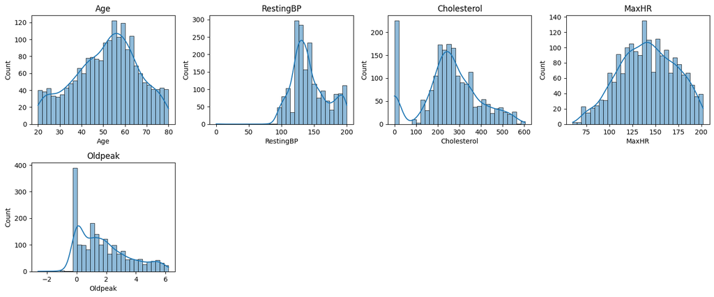

```python
print("\nDISTRIBUTION OF EACH FEATURES VARIABLES BEFORE TREATING OUTLIER\n")
num_cols = ['Age', 'RestingBP', 'Cholesterol', 'MaxHR', 'Oldpeak']
plt.figure(figsize=(15,12))
for i ,col in enumerate(X[num_cols].columns):
    plt.subplot(4,4,i+1)
    sns.histplot(X[col],bins=30,kde=True)
    plt.title(col)
plt.tight_layout()
plt.show()
```

We plot the Histogram for the numerical feature to see the distribution of each features in the datasets before identifying the outlier.

## Identifying and Treating the Outliers

```
========================================== BOXPLOT ==========================================
```

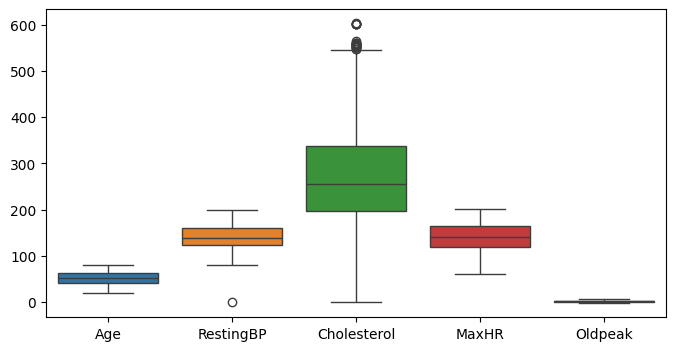

```python
num_cols = ['Age', 'RestingBP', 'Cholesterol', 'MaxHR', 'Oldpeak']

plt.figure(figsize=(8,4))
sns.boxplot(data=X[num_cols])
print('\n========================================== BOXPLOT ==========================================\n')
```

As the above boxplot shows there are som outlier in the cholesterol and only one outlier in the RestingBP.

```python
# Statsitical Method for outlier detection and treating using IQR
print('\n======================= NUMBER OF OUTLIERS IN EACH FEATURES ================================\n')
numerical_cols = ['Age', 'RestingBP', 'Cholesterol', 'MaxHR', 'Oldpeak']
for col in numerical_cols :
    Q1 = X[col].quantile(0.25)
    Q3 = X[col].quantile(0.75)
    IQR = Q3 - Q1

    lower_bound = Q1 - 1.5 * IQR
    upper_bound = Q3 + 1.5 * IQR

    outliers = X[(X[col] < lower_bound) | (X[col] > upper_bound)][col]
    print(f'Number of Outlier in feature {col} is : {outliers.count()}.')

    # Handling the Outlier by IQR method
    X[col] = np.where(X[col] < lower_bound , lower_bound,np.where(X[col] > upper_bound ,upper_bound, X[col]))

print("\n==================================== AFTER HANDLING THE OUTLIER ====================================\n")
for col in numerical_cols :
    Q1 = X[col].quantile(0.25)
    Q3 = X[col].quantile(0.75)
    IQR = Q3 - Q1

    lower_bound = Q1 - 1.5 * IQR
    upper_bound = Q3 + 1.5 * IQR
    outliers = X[(X[col] < lower_bound) | (X[col] > upper_bound)][col]
    print(f'Number of Outlier in feature {col} is : {outliers.count()}.')
```

```
======================= NUMBER OF OUTLIERS IN EACH FEATURES ================================

Number of Outlier in feature Age is : 0.
Number of Outlier in feature RestingBP is : 1.
Number of Outlier in feature Cholesterol is : 25.
Number of Outlier in feature MaxHR is : 0.
Number of Outlier in feature Oldpeak is : 0.

==================================== AFTER HANDLING THE OUTLIER ====================================

Number of Outlier in feature Age is : 0.
Number of Outlier in feature RestingBP is : 0.
Number of Outlier in feature Cholesterol is : 0.
Number of Outlier in feature MaxHR is : 0.
Number of Outlier in feature Oldpeak is : 0.
```

```python
# # univariate Analysis for numerical columns
# num_cols = ['Age', 'RestingBP', 'Cholesterol', 'MaxHR', 'Oldpeak']

# plt.figure(figsize=(8,4))
# sns.boxplot(data=X[num_cols])
# # plt.title('Boxplot ')
```

```python
cat_cols =  ['Sex', 'ChestPainType', 'RestingECG', 'ExerciseAngina', 'ST_Slope']
for col in cat_cols:
    print(f"\nColumn: {col}")
    print(X[col].value_counts())
```

```
Column: Sex
Sex
M    1490
F     428
Name: count, dtype: int64

Column: ChestPainType
ChestPainType
ASY    540
NAP    515
TA     466
ATA    397
Name: count, dtype: int64

Column: RestingECG
RestingECG
Normal    1006
ST         522
LVH        390
Name: count, dtype: int64

Column: ExerciseAngina
ExerciseAngina
N    1049
Y     869
Name: count, dtype: int64

Column: ST_Slope
ST_Slope
Flat    962
Up      694
Down    262
Name: count, dtype: int64
```

- There are no categorical outliers (i.e., no invalid or rare-to-the-point-of-error categories).
- No category contains invalid labels, spelling mistakes , or inconsistent capitalization .
- All categories are mdeically valid , and even less frequent ones like ATA in ChestPainType or Down in ST_Slope are clinically meaningful , not noise.
- Therefore no categorical outlier treatment is requiered.

# Data Visualization

```python
num_cols = ['Age','RestingBP','Cholesterol','MaxHR','Oldpeak']
```

```python
cat_cols
```

```
['Sex', 'ChestPainType', 'RestingECG', 'ExerciseAngina', 'ST_Slope']
```

```python
print("Shape",X.shape)
```

```
Shape (1918, 11)
```

## Univariate Analysis

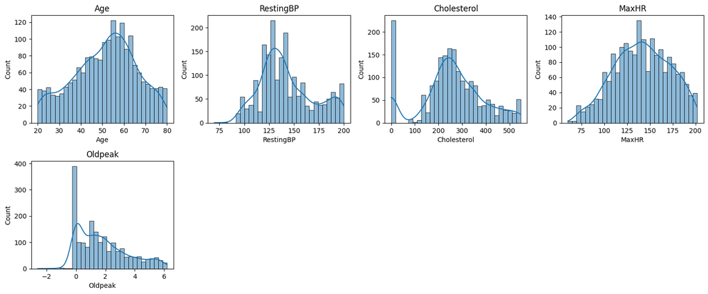

```python
#histogram for the numerical features   (Univariate Analysis)
num_cols = ['Age','RestingBP','Cholesterol','MaxHR','Oldpeak']
plt.figure(figsize=(15,12))
for i ,col in enumerate(X[num_cols].columns):
    plt.subplot(4,4,i+1)
    sns.histplot(X[col],bins=30,kde=True)
    plt.title(col)
plt.tight_layout()
plt.show()
```

## Insights

**Age**

- The age distribution is roughly normal, centered around 50–60 years.
- Most of the population falls between 40 and 70 years, indicating middle-aged to older adults dominate the dataset.

**RestingBP (Resting Blood Pressure)**

- This aligns with medical reality — heart disease risk rises after age 40.
- RestingBP (Resting Blood Pressure)
- The majority of people have RestingBP between 120 and 150 mm Hg, peaking near 130–140.
- The distribution is slightly right-skewed, suggesting a few individuals with elevated BP (>170).

**Cholestrol**

**MaxHR(Maximum Heart Rate Achieved)**

- The distribution is approximately normal, centered around 130–150 bpm.
- Very few individuals have a MaxHR < 90 or > 190.
- Indicates most patients achieved a moderately high heart rate.

**Oldpeak (ST Depression Induced by Exercise)**

- The distribution is right-skewed, with a sharp peak at 0 (no ST depression).
- Most individuals have Oldpeak between 0 and 2, but a few reach > 5.
- High Oldpeak values often correlate with higher heart-disease risk.
- The presence of many zeros shows many patients experienced no exercise-induced depression.

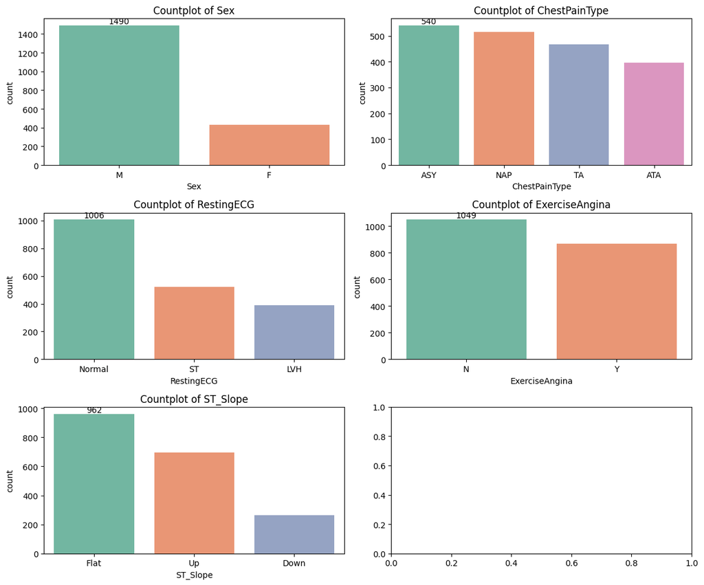

```python
# Countplot for the categorical features (Univariate Analysis)
cat_cols = ['Sex', 'ChestPainType', 'RestingECG', 'ExerciseAngina', 'ST_Slope']
import seaborn as sns
fig , axes = plt.subplots(3,2,figsize=(12,10))
axes = axes.flatten()
for i , col in enumerate(cat_cols):
    sns.countplot(data=data,x=col,ax=axes[i],order=data[col].value_counts().index,palette='Set2')
    axes[i].set_title(f'Countplot of {col}')
    axes[i].bar_label(axes[i].containers[0])
plt.tight_layout()
plt.show()
```

## Bivariate Analysis

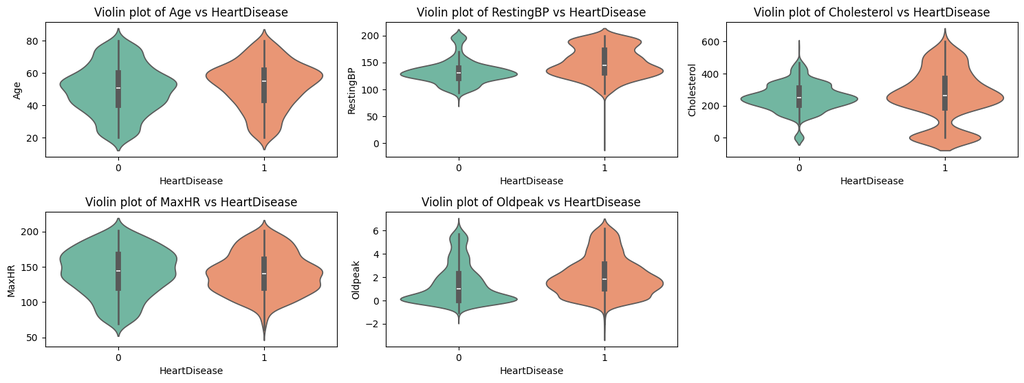

```python
#Bivariate anaylisis for numerical columns
num_cols = ['Age','RestingBP','Cholesterol','MaxHR','Oldpeak']
plt.figure(figsize=(15,8))
for i , col in enumerate(num_cols,1):
    plt.subplot(3,3,i)
    sns.violinplot(x='HeartDisease', y=col,data=data,palette='Set2')
    plt.title(f'Violin plot of {col} vs HeartDisease')

plt.tight_layout()
plt.show()
```

```python
# sns.pairplot(data[num_cols + ['HeartDisease']] , hue ='HeartDisease' ,palette='Set1',diag_kind='kde')
# plt.show()
```

```
============================================================= BIVARIATE ANALYSIS FOR CATEGORICAL FEATURES =====================================================================
```

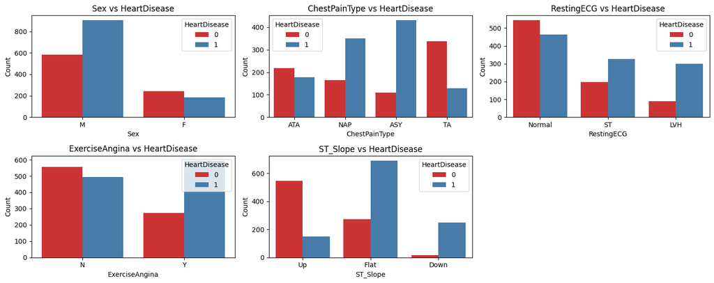

```python
print('\n============================================================= BIVARIATE ANALYSIS FOR CATEGORICAL FEATURES =====================================================================\n')

plt.figure(figsize=(15,6))
for i, col in enumerate(cat_cols, 1):
    plt.subplot(2, 3, i)   # 2 rows, 3 columns
    sns.countplot(data=X, x=col, hue=y, palette='Set1')
    plt.title(f'{col} vs HeartDisease')
    plt.xlabel(col)
    plt.ylabel('Count')
plt.tight_layout()
plt.show()
```

## Multivariate Analysis

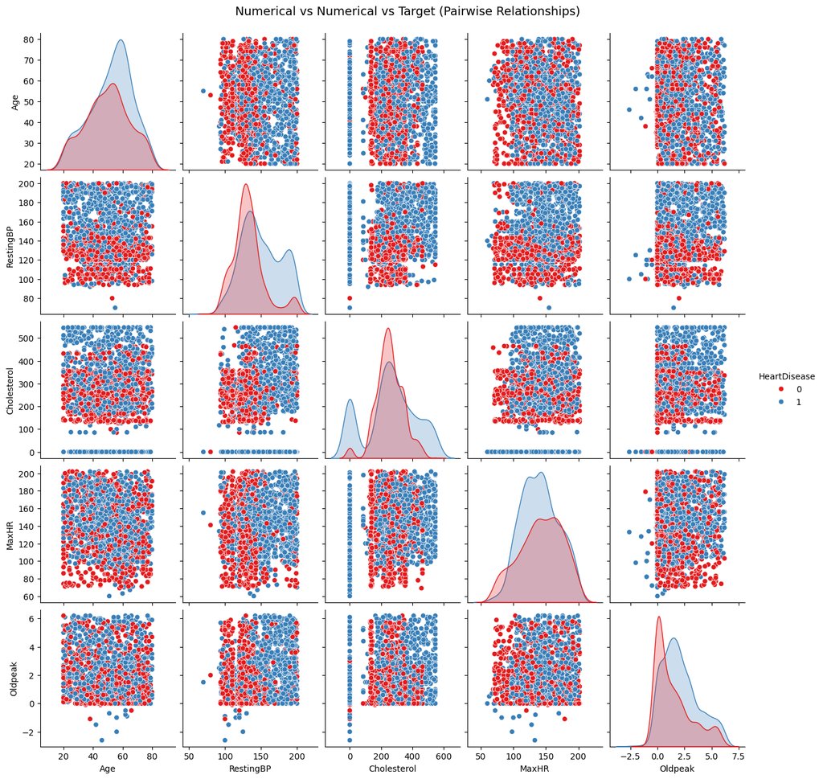

```python
# Numerical + Numerical + Target
df_viz = X.copy()
df_viz = df_viz.drop('FastingBS',axis=1)
df_viz['HeartDisease'] = y

num_cols = ['Age','RestingBP','Cholesterol','MaxHR','Oldpeak']

sns.pairplot(data=df_viz,hue='HeartDisease',diag_kind='kde',palette='Set1')
plt.suptitle("Numerical vs Numerical vs Target (Pairwise Relationships)",y=1.02,fontsize=14)
plt.show()
```

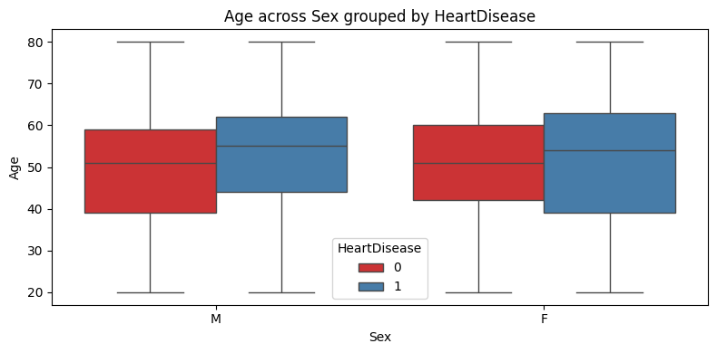

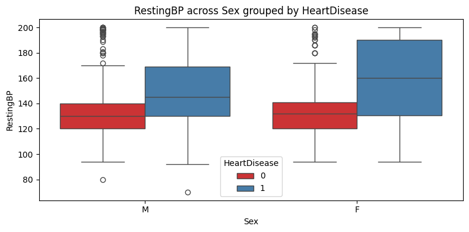

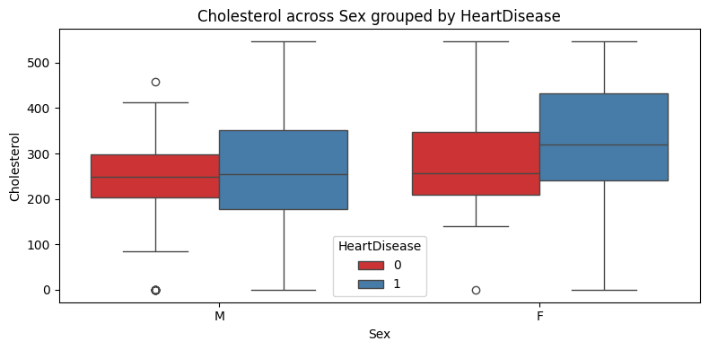

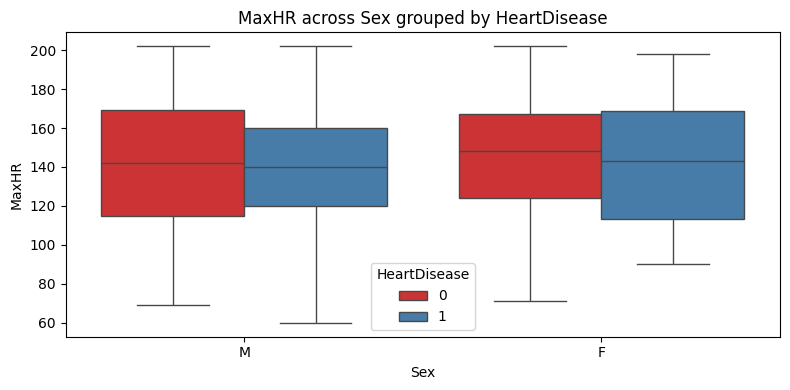

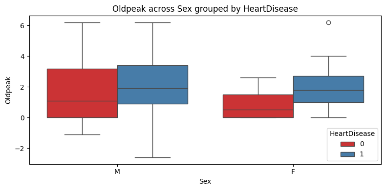

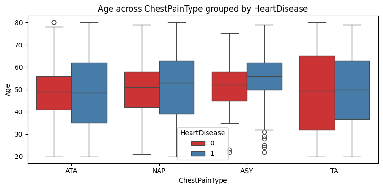

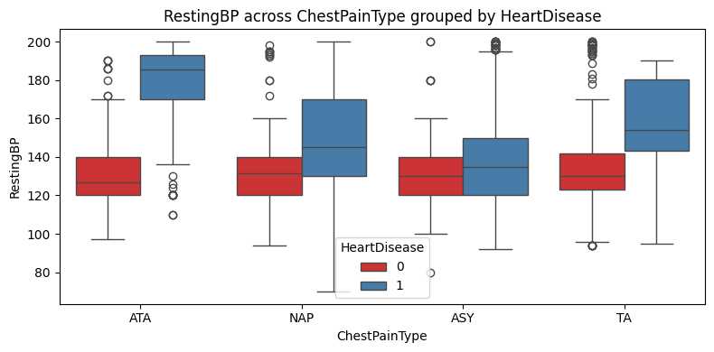

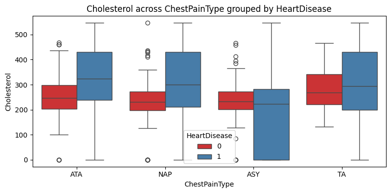

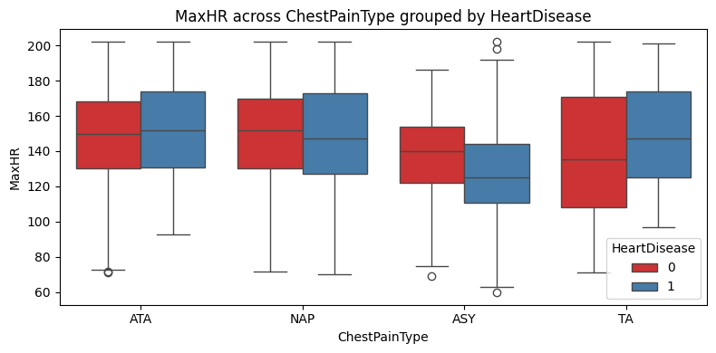

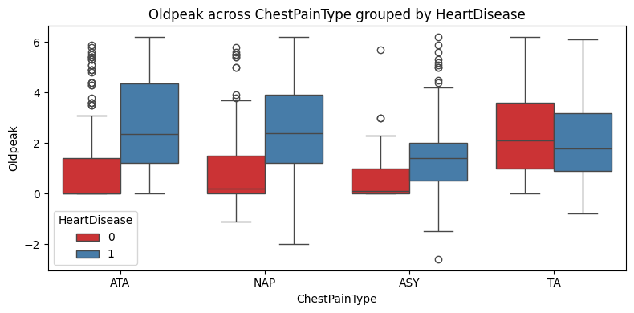

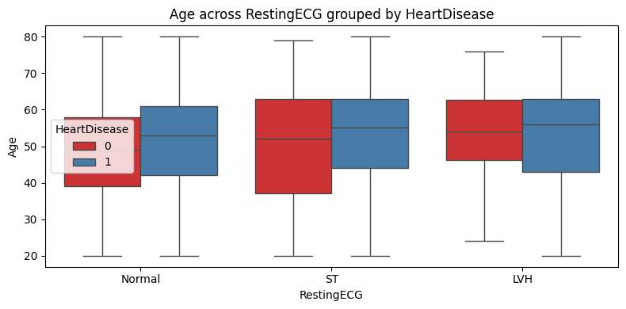

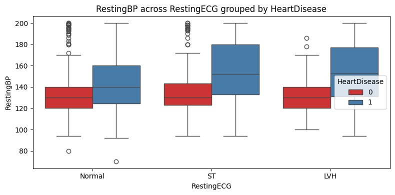

[13 more figures not shown]

```python
# Numerical + categorical + Target
cat_cols = ['Sex', 'ChestPainType', 'RestingECG', 'ExerciseAngina', 'ST_Slope']
num_cols = ['Age', 'RestingBP', 'Cholesterol', 'MaxHR', 'Oldpeak']

for cat in cat_cols :
    for num in num_cols :
        plt.figure(figsize=(8,4))
        sns.boxplot(data=df_viz,x=cat,y= num , hue= 'HeartDisease' ,palette='Set1')
        plt.title(f'{num} across {cat} grouped by HeartDisease')
        plt.tight_layout()
        plt.show()
```

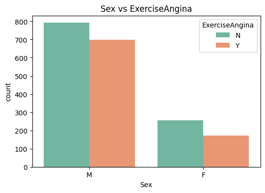

| Sex | HeartDisease ExerciseAngina | 0 | 1 |
| --- | --- | --- | --- |
| F | N | 0.68 | 0.32 |
|  | Y | 0.40 | 0.60 |
| M | N | 0.48 | 0.52 |
|  | Y | 0.29 | 0.71 |

```python
# cat + cat  + target
# Sex vs ExerciseAngina vs HeartDisease
plt.figure(figsize=(6,4))
sns.countplot(data=df_viz, x='Sex', hue='ExerciseAngina', palette='Set2')
plt.title('Sex vs ExerciseAngina')
plt.show()

# With target insight
pd.crosstab([df_viz['Sex'], df_viz['ExerciseAngina']], df_viz['HeartDisease'], normalize='index').round(2)
```

```
===============================================================================

CORRELATION ANALYSIS
==================================================================================
```

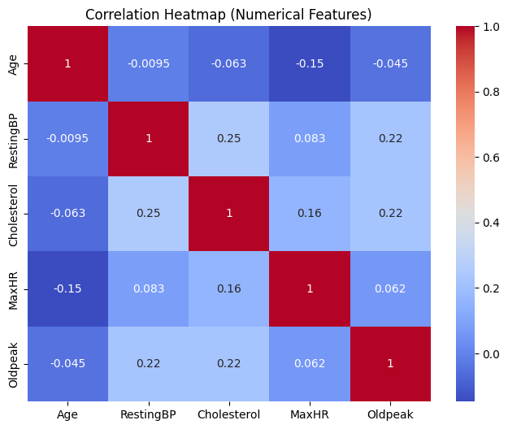

```python
print("\n===============================================================================\n")
print("CORRELATION ANALYSIS")
print('==================================================================================')

num_cols = ['Age', 'RestingBP', 'Cholesterol', 'MaxHR', 'Oldpeak']
plt.figure(figsize=(8,6))
sns.heatmap(X[num_cols].corr(), annot=True, cmap='coolwarm')
plt.title("Correlation Heatmap (Numerical Features)")
plt.show()
```

# DATA PREPROCESSING FOR MACHINE LEARNING

```python
# One - Hot Encoding for Ordinal Features

print('\n=================================================== ENCODING BINARY VARIABLES USING LABEL ENCODER ==============================================\n')
binary_cols = ['Sex' ,'ExerciseAngina']
label_encoder = LabelEncoder()
for col in binary_cols :
    X[col] = label_encoder.fit_transform(X[col])
    print(f"Encoding {col} variable ..")

print('\n=================================================== ENCODING ORDINAL VARIABLES USING ONEHOT ENCODER ==============================================\n')

multi_cols = ['ChestPainType','RestingECG','ST_Slope']

# Onehot Encoder
# Initialize OneHotEncoder
onehot_encoder = OneHotEncoder(drop='first', sparse_output=False)

# Fit and transform only the multi-class categorical columns
encoded_array = onehot_encoder.fit_transform(X[multi_cols])

# Converting encoded data to DataFrame
encoded_df = pd.DataFrame(encoded_array,
                          columns=onehot_encoder.get_feature_names_out(multi_cols),
                          index=X.index)

# Drop the original categorical columns and add the new one-hot encoded ones
X = pd.concat([X.drop(columns=multi_cols), encoded_df], axis=1)
for col in multi_cols:
    print(f'Encoding {col} variable ....')
# Check the encoded dataset
print("\n==================================================== AFTER PERFORMING ENCODING DATASET TYPE =================================================", X.shape)
print('\n')
X.head()
```

```
=================================================== ENCODING BINARY VARIABLES USING LABEL ENCODER ==============================================

Encoding Sex variable ..
Encoding ExerciseAngina variable ..

=================================================== ENCODING ORDINAL VARIABLES USING ONEHOT ENCODER ==============================================

Encoding ChestPainType variable ....
Encoding RestingECG variable ....
Encoding ST_Slope variable ....

==================================================== AFTER PERFORMING ENCODING DATASET TYPE ================================================= (1918, 15)
```

|  | Age | Sex | RestingBP | Cholesterol | FastingBS | MaxHR | ExerciseAngina | Oldpeak | ChestPainType_ATA | ChestPainType_NAP | ChestPainType_TA | RestingECG_Normal | RestingECG_ST | ST_Slope_Flat | ST_Slope_Up |
| --- | --- | --- | --- | --- | --- | --- | --- | --- | --- | --- | --- | --- | --- | --- | --- |
| 0 | 40.0 | 1 | 140.0 | 289.0 | 0 | 172.0 | 0 | 0.0 | 1.0 | 0.0 | 0.0 | 1.0 | 0.0 | 0.0 | 1.0 |
| 1 | 49.0 | 0 | 160.0 | 180.0 | 0 | 156.0 | 0 | 1.0 | 0.0 | 1.0 | 0.0 | 1.0 | 0.0 | 1.0 | 0.0 |
| 2 | 37.0 | 1 | 130.0 | 283.0 | 0 | 98.0 | 0 | 0.0 | 1.0 | 0.0 | 0.0 | 0.0 | 1.0 | 0.0 | 1.0 |
| 3 | 48.0 | 0 | 138.0 | 214.0 | 0 | 108.0 | 1 | 1.5 | 0.0 | 0.0 | 0.0 | 1.0 | 0.0 | 1.0 | 0.0 |
| 4 | 54.0 | 1 | 150.0 | 195.0 | 0 | 122.0 | 0 | 0.0 | 0.0 | 1.0 | 0.0 | 1.0 | 0.0 | 0.0 | 1.0 |

```python
print("\n=================================================================================")
print("\n============================== SCALING FEATURES BY STANDARD SCALER =============================================")
print("\n=================================================================================")
from sklearn.preprocessing import StandardScaler

num_cols = ['Age', 'RestingBP', 'Cholesterol', 'MaxHR', 'Oldpeak']

scaler = StandardScaler()
X[num_cols] = scaler.fit_transform(X[num_cols])

print("\nFeatures scaled using StandardScaler\n")
X.head()
```

```
=================================================================================

============================== SCALING FEATURES BY STANDARD SCALER =============================================

=================================================================================

Features scaled using StandardScaler
```

|  | Age | Sex | RestingBP | Cholesterol | FastingBS | MaxHR | ExerciseAngina | Oldpeak | ChestPainType_ATA | ChestPainType_NAP | ChestPainType_TA | RestingECG_Normal | RestingECG_ST | ST_Slope_Flat | ST_Slope_Up |
| --- | --- | --- | --- | --- | --- | --- | --- | --- | --- | --- | --- | --- | --- | --- | --- |
| 0 | -0.772675 | 1 | -0.094172 | 0.237392 | 0 | 1.001710 | 0 | -1.075985 | 1.0 | 0.0 | 0.0 | 1.0 | 0.0 | 0.0 | 1.0 |
| 1 | -0.156463 | 0 | 0.652660 | -0.578155 | 0 | 0.479162 | 0 | -0.490078 | 0.0 | 1.0 | 0.0 | 1.0 | 0.0 | 1.0 | 0.0 |
| 2 | -0.978079 | 1 | -0.467588 | 0.192499 | 0 | -1.415077 | 0 | -1.075985 | 1.0 | 0.0 | 0.0 | 0.0 | 1.0 | 0.0 | 1.0 |
| 3 | -0.224931 | 0 | -0.168855 | -0.323764 | 0 | -1.088484 | 1 | -0.197125 | 0.0 | 0.0 | 0.0 | 1.0 | 0.0 | 1.0 | 0.0 |
| 4 | 0.185877 | 1 | 0.279244 | -0.465924 | 0 | -0.631254 | 0 | -1.075985 | 0.0 | 1.0 | 0.0 | 1.0 | 0.0 | 0.0 | 1.0 |

```python
X.shape
```

```
(1918, 15)
```

```python
print("\n=================================================================================")
print("\nSPLITTING DATA INTO TRAIN AND TESTS SETS")
print("\n=================================================================================")
from sklearn.model_selection import train_test_split
X_train , X_test , y_train , y_test = train_test_split( X , y , test_size=0.2 , random_state = 42 ,stratify=y )
print(f"\nFeature matrix shape: {X.shape}")
print(f"\nTarget vector shape: {y.shape}")
print(f"\nX_train shape: {X_train.shape}")
print(f"\nX_test shape: {X_test.shape}")
print(f"\ny_train shape: {y_train.shape}")
print(f"\ny_test shape: {y_test.shape}")
```

```
=================================================================================

SPLITTING DATA INTO TRAIN AND TESTS SETS

=================================================================================

Feature matrix shape: (1918, 15)

Target vector shape: (1918,)

X_train shape: (1534, 15)

X_test shape: (384, 15)

y_train shape: (1534,)

y_test shape: (384,)
```

```python
from sklearn.decomposition import PCA

for i in range(1, 16):
    pca = PCA(n_components=i)
    X_train_trf = pca.fit_transform(X_train)
    X_test_trf = pca.transform(X_test)

    # rf_clf = RandomForestClassifier(n_estimators=100,
    #                                 max_depth=10,
    #                                 random_state=42,
    #                                 n_jobs=-1)
    rf_clf = KNeighborsClassifier()

    rf_clf.fit(X_train_trf, y_train)

    print(f'===================== RESULTS FOR PRINCIPAL COMPONENTS : {i} =============\n')

    # TRAIN METRICS
    y_train_pred = rf_clf.predict(X_train_trf)
    y_train_prob = rf_clf.predict_proba(X_train_trf)[:, 1]

    print("\n========== TRAINING METRICS ==========\n")
    print("Accuracy :", accuracy_score(y_train, y_train_pred))
    print("Precision:", precision_score(y_train, y_train_pred))
    print("Recall   :", recall_score(y_train, y_train_pred))
    print("F1 Score :", f1_score(y_train, y_train_pred))
    print("AUC-ROC  :", roc_auc_score(y_train, y_train_prob))
    print("\nConfusion Matrix:\n", confusion_matrix(y_train, y_train_pred))
    print("\nClassification Report:\n", classification_report(y_train, y_train_pred))

    # TEST METRICS
    y_test_pred = rf_clf.predict(X_test_trf)
    y_test_prob = rf_clf.predict_proba(X_test_trf)[:, 1]

    print("\n========== TESTING METRICS ==========\n")
    print("Accuracy :", accuracy_score(y_test, y_test_pred))
    print("Precision:", precision_score(y_test, y_test_pred))
    print("Recall   :", recall_score(y_test, y_test_pred))
    print("F1 Score :", f1_score(y_test, y_test_pred))
    print("AUC-ROC  :", roc_auc_score(y_test, y_test_prob))
    print("\nConfusion Matrix:\n", confusion_matrix(y_test, y_test_pred))
    print("\nClassification Report:\n", classification_report(y_test, y_test_pred))
```

```
===================== RESULTS FOR PRINCIPAL COMPONENTS : 1 =============


========== TRAINING METRICS ==========

Accuracy : 0.7398956975228161
Precision: 0.7585071350164654
Recall   : 0.7942528735632184
F1 Score : 0.7759685569904547
AUC-ROC  : 0.8196354383049439

Confusion Matrix:
 [[444 220]
 [179 691]]

Classification Report:
               precision    recall  f1-score   support

           0       0.71      0.67      0.69       664
           1       0.76      0.79      0.78       870

    accuracy                           0.74      1534
   macro avg       0.74      0.73      0.73      1534
weighted avg       0.74      0.74      0.74      1534


========== TESTING METRICS ==========

Accuracy : 0.5911458333333334
Precision: 0.6265560165975104
Recall   : 0.6926605504587156
F1 Score : 0.6579520697167756
AUC-ROC  : 0.6340637780479716

Confusion Matrix:
 [[ 76  90]
 [ 67 151]]

Classification Report:
               precision    recall  f1-score   support
```

[output cut: 664 more lines]

```
AUC-ROC  : 0.9333342544489887

Confusion Matrix:
 [[143  23]
 [ 20 198]]

Classification Report:
               precision    recall  f1-score   support

           0       0.88      0.86      0.87       166
           1       0.90      0.91      0.90       218

    accuracy                           0.89       384
   macro avg       0.89      0.88      0.89       384
weighted avg       0.89      0.89      0.89       384
```

# Statistical Modeling & Machine Learning¶

## Models to Train:

- **LOGISTIC REGRESSION**-Baseline Linear Model
- **K-NEAREST NEIGHBORS(KNN)**-Instance-based learning
- **NAIVE BAYES**-Probabilistic classifier
- **SUPPORT VECTOR MACHINE(SVM)**-Kernel-based classifier
- **DECISION TREE**-
- **RANDOM FOREST**-

# K-NEAREST NEIGHBORS(KNN)

```python
print('\n===============================================================================\n')
print('KNeighborsClassifier (KNN)')
print('\n================================================================================\n')

knn_clf = KNeighborsClassifier(n_neighbors=5)
knn_clf.fit(X_train , y_train)

#Prediction

y_train_pred = knn_clf.predict(X_train)
y_train_prob = knn_clf.predict_proba(X_train)[:, 1]

print("\n========== TRAINING METRICS ==========\n")
print("Accuracy :", accuracy_score(y_train, y_train_pred))
print("Precision:", precision_score(y_train, y_train_pred))
print("Recall   :", recall_score(y_train, y_train_pred))
print("F1 Score :", f1_score(y_train, y_train_pred))
print("AUC-ROC  :", roc_auc_score(y_train, y_train_prob))
print("\nConfusion Matrix:\n", confusion_matrix(y_train, y_train_pred))
print("\nClassification Report:\n", classification_report(y_train, y_train_pred))


y_test_pred = knn_clf.predict(X_test)
y_test_prob = knn_clf.predict_proba(X_test)[:, 1]

print("\n========== TESTING METRICS ==========\n")
print("Accuracy :", accuracy_score(y_test, y_test_pred))
print("Precision:", precision_score(y_test, y_test_pred))
print("Recall   :", recall_score(y_test, y_test_pred))
print("F1 Score :", f1_score(y_test, y_test_pred))
print("AUC-ROC  :", roc_auc_score(y_test, y_test_prob))
print("\nConfusion Matrix:\n", confusion_matrix(y_test, y_test_pred))
print("\nClassification Report:\n", classification_report(y_test, y_test_pred))

result=[]
result.append(
    {
        "Model": "KNN",
        "Accuracy": accuracy_score(y_test, y_test_pred),
        "Precision": precision_score(y_test, y_test_pred),
        "Recall": recall_score(y_test, y_test_pred),
        "F1 Score": f1_score(y_test, y_test_pred),
        "AUC-ROC Score" : roc_auc_score(y_test, y_test_prob)
    }
)
```

```
===============================================================================

KNeighborsClassifier (KNN)

================================================================================


========== TRAINING METRICS ==========

Accuracy : 0.910039113428944
Precision: 0.9112359550561798
Recall   : 0.9321839080459771
F1 Score : 0.9215909090909091
AUC-ROC  : 0.9687179753496745

Confusion Matrix:
 [[585  79]
 [ 59 811]]

Classification Report:
               precision    recall  f1-score   support

           0       0.91      0.88      0.89       664
           1       0.91      0.93      0.92       870

    accuracy                           0.91      1534
   macro avg       0.91      0.91      0.91      1534
weighted avg       0.91      0.91      0.91      1534


========== TESTING METRICS ==========

Accuracy : 0.8880208333333334
Precision: 0.8959276018099548
Recall   : 0.908256880733945
F1 Score : 0.9020501138952164
AUC-ROC  : 0.9333342544489887

Confusion Matrix:
 [[143  23]
 [ 20 198]]

Classification Report:
               precision    recall  f1-score   support

           0       0.88      0.86      0.87       166
           1       0.90      0.91      0.90       218

    accuracy                           0.89       384
   macro avg       0.89      0.88      0.89       384
weighted avg       0.89      0.89      0.89       384
```

# Observations for KNN Model

**KNN** provides a solid baseline performance with high recall and AUC, making it suitable for initial classification benchmarks.

- The Overall Performance of the KNN model performed well achieving recall 90.8% on the test data.
- The difference between train and test metrics is small it means the model is not overfitting and generalizes well.
- It detects most positive cases , and good separate the two classes.

## Hyperparamter Tuning

```python
# n_neighbors = Number of neighbors to use by default for kneighbors queries
# DEFINING THE HYPERPARAMETER GRID
param_knn = {
    'n_neighbors' : np.arange(1,15),
    'weights' :['uniform','distance'],
    'algorithm':['auto','ball_tree','kd_tree','brute'],
    'p':[1,2]
}

# DEFINING THE KNN CLASSIFIER
knn_clf = KNeighborsClassifier()

# GridSearchCV with F1 scoring
grid_search = GridSearchCV(
    estimator=knn_clf,
    param_grid=param_knn,
    scoring='f1',
    n_jobs=-1,
    cv=5
)


grid_search.fit(X_train, y_train)

print('\nBest Parameters :\n', grid_search.best_params_)
print('\nBest Cross_val F1 :\n', grid_search.best_score_)

# Get best model
best_knn = grid_search.best_estimator_

# ----------------------------
# TRAINING METRICS
# ----------------------------
y_train_pred = best_knn.predict(X_train)
y_train_prob = best_knn.predict_proba(X_train)[:, 1]

print("\n========== TRAINING METRICS ==========")
print("Accuracy :", accuracy_score(y_train, y_train_pred))
print("Precision:", precision_score(y_train, y_train_pred))
print("Recall   :", recall_score(y_train, y_train_pred))
print("F1 Score :", f1_score(y_train, y_train_pred))
print("AUC-ROC  :", roc_auc_score(y_train, y_train_prob))
print("\nConfusion Matrix:\n", confusion_matrix(y_train, y_train_pred))
print("\nClassification Report:\n", classification_report(y_train, y_train_pred))

# ----------------------------
# TESTING METRICS
# ----------------------------
y_test_pred = best_knn.predict(X_test)
y_test_prob = best_knn.predict_proba(X_test)[:, 1]

print("\n========== TESTING METRICS ==========\n")
print("Accuracy :", accuracy_score(y_test, y_test_pred))
print("Precision:", precision_score(y_test, y_test_pred))
print("Recall   :", recall_score(y_test, y_test_pred))
print("F1 Score :", f1_score(y_test, y_test_pred))
print("AUC-ROC  :", roc_auc_score(y_test, y_test_prob))
print("\nConfusion Matrix:\n", confusion_matrix(y_test, y_test_pred))
print("\nClassification Report:\n", classification_report(y_test, y_test_pred))
```

```
Best Parameters :
 {'algorithm': 'auto', 'n_neighbors': np.int64(7), 'p': 1, 'weights': 'uniform'}

Best Cross_val F1 :
 0.8900097430276457

========== TRAINING METRICS ==========
Accuracy : 0.9041720990873533
Precision: 0.906636670416198
Recall   : 0.9264367816091954
F1 Score : 0.9164297896532121
AUC-ROC  : 0.9665896343996677

Confusion Matrix:
 [[581  83]
 [ 64 806]]

Classification Report:
               precision    recall  f1-score   support

           0       0.90      0.88      0.89       664
           1       0.91      0.93      0.92       870

    accuracy                           0.90      1534
   macro avg       0.90      0.90      0.90      1534
weighted avg       0.90      0.90      0.90      1534


========== TESTING METRICS ==========

Accuracy : 0.8854166666666666
Precision: 0.8990825688073395
Recall   : 0.8990825688073395
F1 Score : 0.8990825688073395
AUC-ROC  : 0.9400906377804796

Confusion Matrix:
 [[144  22]
 [ 22 196]]

Classification Report:
               precision    recall  f1-score   support

           0       0.87      0.87      0.87       166
           1       0.90      0.90      0.90       218

    accuracy                           0.89       384
   macro avg       0.88      0.88      0.88       384
weighted avg       0.89      0.89      0.89       384
```

# Observation

After performing the Hyperparameter tuning there is no improvement in the recall and f1 score the untuned model perform better than the tuned model . so, the untuned KNN model will be taken for the model evaluation.

# Naive Bayes

```python
# Build a Gaussian Classifier
model = GaussianNB()

# model training
model.fit(X_train , y_train)

#Prediction

y_train_pred = model.predict(X_train)
y_train_prob = model.predict_proba(X_train)[:, 1]

print("\n========== TRAINING METRICS ==========\n")
print("Accuracy :", accuracy_score(y_train, y_train_pred))
print("Precision:", precision_score(y_train, y_train_pred))
print("Recall   :", recall_score(y_train, y_train_pred))
print("F1 Score :", f1_score(y_train, y_train_pred))
print("AUC-ROC  :", roc_auc_score(y_train, y_train_prob))
print("\nConfusion Matrix:\n", confusion_matrix(y_train, y_train_pred))
print("\nClassification Report:\n", classification_report(y_train, y_train_pred))

y_test_pred = model.predict(X_test)
y_test_prob = model.predict_proba(X_test)[:, 1]

print("\n========== TESTING METRICS ==========\n")
print("Accuracy :", accuracy_score(y_test, y_test_pred))
print("Precision:", precision_score(y_test, y_test_pred))
print("Recall   :", recall_score(y_test, y_test_pred))
print("F1 Score :", f1_score(y_test, y_test_pred))
print("AUC-ROC  :", roc_auc_score(y_test, y_test_prob))
print("\nConfusion Matrix:\n", confusion_matrix(y_test, y_test_pred))
print("\nClassification Report:\n", classification_report(y_test, y_test_pred))

result.append(
    {
        "Model": "Naive Bayes",
        "Accuracy": accuracy_score(y_test, y_test_pred),
        "Precision": precision_score(y_test, y_test_pred),
        "Recall": recall_score(y_test, y_test_pred),
        "F1 Score": f1_score(y_test, y_test_pred),
        "AUC-ROC Score" : roc_auc_score(y_test, y_test_prob)
    }
)
```

```
========== TRAINING METRICS ==========

Accuracy : 0.8402868318122555
Precision: 0.8547105561861521
Recall   : 0.8655172413793103
F1 Score : 0.8600799543118218
AUC-ROC  : 0.9117954576928402

Confusion Matrix:
 [[536 128]
 [117 753]]

Classification Report:
               precision    recall  f1-score   support

           0       0.82      0.81      0.81       664
           1       0.85      0.87      0.86       870

    accuracy                           0.84      1534
   macro avg       0.84      0.84      0.84      1534
weighted avg       0.84      0.84      0.84      1534


========== TESTING METRICS ==========

Accuracy : 0.8619791666666666
Precision: 0.8837209302325582
Recall   : 0.8715596330275229
F1 Score : 0.8775981524249422
AUC-ROC  : 0.9216867469879518

Confusion Matrix:
 [[141  25]
 [ 28 190]]

Classification Report:
               precision    recall  f1-score   support

           0       0.83      0.85      0.84       166
           1       0.88      0.87      0.88       218

    accuracy                           0.86       384
   macro avg       0.86      0.86      0.86       384
weighted avg       0.86      0.86      0.86       384
```

# Observation

# LOGISTIC REGRESSION

```python
# Buliding a classifier

print('\n=============================================== LOGISTIC REGRESSION =======================================================\n')
lg_clf = LogisticRegression(max_iter=1000, random_state=42)
lg_clf.fit(X_train , y_train)


#Prediction

y_train_pred = lg_clf.predict(X_train)
y_train_prob = lg_clf.predict_proba(X_train)[:, 1]

print("\n========== TRAINING METRICS ==========\n")
print("Accuracy :", accuracy_score(y_train, y_train_pred))
print("Precision:", precision_score(y_train, y_train_pred))
print("Recall   :", recall_score(y_train, y_train_pred))
print("F1 Score :", f1_score(y_train, y_train_pred))
print("AUC-ROC  :", roc_auc_score(y_train, y_train_prob))
print("\nConfusion Matrix:\n", confusion_matrix(y_train, y_train_pred))
print("\nClassification Report:\n", classification_report(y_train, y_train_pred))

y_test_pred = lg_clf.predict(X_test)
y_test_prob = lg_clf.predict_proba(X_test)[:, 1]

print("\n========== TESTING METRICS ==========\n")
print("Accuracy :", accuracy_score(y_test, y_test_pred))
print("Precision:", precision_score(y_test, y_test_pred))
print("Recall   :", recall_score(y_test, y_test_pred))
print("F1 Score :", f1_score(y_test, y_test_pred))
print("AUC-ROC  :", roc_auc_score(y_test, y_test_prob))
print("\nConfusion Matrix:\n", confusion_matrix(y_test, y_test_pred))
print("\nClassification Report:\n", classification_report(y_test, y_test_pred))

result.append(
    {
        "Model": "Logistic Regression",
        "Accuracy": accuracy_score(y_test, y_test_pred),
        "Precision": precision_score(y_test, y_test_pred),
        "Recall": recall_score(y_test, y_test_pred),
        "F1 Score": f1_score(y_test, y_test_pred),
        "AUC-ROC Score" : roc_auc_score(y_test, y_test_prob)
    }
)
```

```
=============================================== LOGISTIC REGRESSION =======================================================


========== TRAINING METRICS ==========

Accuracy : 0.8507170795306388
Precision: 0.8629671574178935
Recall   : 0.8758620689655172
F1 Score : 0.8693667997718197
AUC-ROC  : 0.9205373217005954

Confusion Matrix:
 [[543 121]
 [108 762]]

Classification Report:
               precision    recall  f1-score   support

           0       0.83      0.82      0.83       664
           1       0.86      0.88      0.87       870

    accuracy                           0.85      1534
   macro avg       0.85      0.85      0.85      1534
weighted avg       0.85      0.85      0.85      1534


========== TESTING METRICS ==========

Accuracy : 0.875
Precision: 0.8863636363636364
Recall   : 0.8944954128440367
F1 Score : 0.8904109589041096
AUC-ROC  : 0.9328506687299657

Confusion Matrix:
 [[141  25]
 [ 23 195]]

Classification Report:
               precision    recall  f1-score   support

           0       0.86      0.85      0.85       166
           1       0.89      0.89      0.89       218

    accuracy                           0.88       384
   macro avg       0.87      0.87      0.87       384
weighted avg       0.87      0.88      0.87       384
```

# Insights

- Logistic Regression correctly identifies 89.4% of actual heart-disease patients on the test set — this is highly important in medical prediction.
- F1 around to 0.89 means the model performs very reliably for real-world medical screening.
- An AUC above 0.93 means: Logistic Regression is excellent at separating patients with heart disease from those without it.

Logistic Regression performed strongly on this medical dataset, achieving a recall of 89.4%, F1-score of 0.89, and an AUC of 0.932 on the test set. These metrics show that the model reliably detects heart-disease patients with very few misses. The close train–test performance proves excellent generalization with no overfitting. Logistic Regression serves as a highly stable and medically reliable model for initial heart-disease prediction

# SUPPORT VECTOR MACHINE(SVM)

```python
print('\n========================================================== SVM ==============================================================')

svc_clf = SVC(kernel ='rbf' , random_state = 42 , probability = True)
svc_clf.fit(X_train , y_train)


#Prediction

y_train_pred = svc_clf.predict(X_train)
y_train_prob = svc_clf.predict_proba(X_train)[:, 1]

print("\n========== TRAINING METRICS ==========\n")
print("Accuracy :", accuracy_score(y_train, y_train_pred))
print("Precision:", precision_score(y_train, y_train_pred))
print("Recall   :", recall_score(y_train, y_train_pred))
print("F1 Score :", f1_score(y_train, y_train_pred))
print("AUC-ROC  :", roc_auc_score(y_train, y_train_prob))
print("\nConfusion Matrix:\n", confusion_matrix(y_train, y_train_pred))
print("\nClassification Report:\n", classification_report(y_train, y_train_pred))

y_test_pred = svc_clf.predict(X_test)
y_test_prob = svc_clf.predict_proba(X_test)[:, 1]

print("\n========== TESTING METRICS ==========\n")
print("Accuracy :", accuracy_score(y_test, y_test_pred))
print("Precision:", precision_score(y_test, y_test_pred))
print("Recall   :", recall_score(y_test, y_test_pred))
print("F1 Score :", f1_score(y_test, y_test_pred))
print("AUC-ROC  :", roc_auc_score(y_test, y_test_prob))
print("\nConfusion Matrix:\n", confusion_matrix(y_test, y_test_pred))
print("\nClassification Report:\n", classification_report(y_test, y_test_pred))

result.append(
    {
        "Model": "SVM",
        "Accuracy": accuracy_score(y_test, y_test_pred),
        "Precision": precision_score(y_test, y_test_pred),
        "Recall": recall_score(y_test, y_test_pred),
        "F1 Score": f1_score(y_test, y_test_pred),
        "AUC-ROC Score" : roc_auc_score(y_test, y_test_prob)
    }
)
```

```
========================================================== SVM ==============================================================

========== TRAINING METRICS ==========

Accuracy : 0.9132985658409387
Precision: 0.9135802469135802
Recall   : 0.9356321839080459
F1 Score : 0.9244747302668939
AUC-ROC  : 0.9612873909430827

Confusion Matrix:
 [[587  77]
 [ 56 814]]

Classification Report:
               precision    recall  f1-score   support

           0       0.91      0.88      0.90       664
           1       0.91      0.94      0.92       870

    accuracy                           0.91      1534
   macro avg       0.91      0.91      0.91      1534
weighted avg       0.91      0.91      0.91      1534


========== TESTING METRICS ==========

Accuracy : 0.9140625
Precision: 0.9147982062780269
Recall   : 0.9357798165137615
F1 Score : 0.9251700680272109
AUC-ROC  : 0.9551785122139936

Confusion Matrix:
 [[147  19]
 [ 14 204]]

Classification Report:
               precision    recall  f1-score   support

           0       0.91      0.89      0.90       166
           1       0.91      0.94      0.93       218

    accuracy                           0.91       384
   macro avg       0.91      0.91      0.91       384
weighted avg       0.91      0.91      0.91       384
```

# Insights

- The SVM model correctly identifies 93.5%+ of all patients who truly have heart disease. This is extremely important in medical diagnosis since false negatives must be minimized.
- A Test F1 of 0.925 indicates very strong, clinically reliable performance.
- AUC above 0.95 means the model is very effective at separating: Patients with heart disease and Patients without disease

SVM performed well for heart-disease prediction. It achieved a recall of 93.5%, ensuring that most patients with heart disease are correctly identified. The model’s F1-score of 0.925 and AUC of 0.9551 demonstrate strong balance and excellent class separation. The close match between train and test metrics shows that the model generalizes well without overfitting.

## Hyperparamter Tuning

```python
# DEFINING THE HYPERPARAMETER GRID

param_grid = {
    'C': [0.1 , 1 , 10 , 100 , 1000],
    'gamma' : [1 , 0.1 , 0.01, 0.001 , 0.0001],
    'kernel' : ['rbf']
}
# DEFINING THE SVC CLASSIFIER
svc_clf = SVC(probability=True)

grid_search = GridSearchCV(
    estimator=svc_clf,
    param_grid=param_grid,
    # scoring = 'balanced_accuracy',
    scoring = 'f1',
    n_jobs = -1,
    cv = 5,
    verbose=1
)

# Fit
grid_search.fit(X_train , y_train)
print('Best Parameters :',grid_search.best_params_)
print('Best Cross_val Accuracy :',grid_search.best_score_)

# Evaluating the best model on the full dataset
best_svc = grid_search.best_estimator_
y_train_pred = best_svc.predict(X_train)
y_train_prob = best_svc.predict_proba(X_train)[:, 1]

print("\n========== TRAINING METRICS ==========")
print("Accuracy :", accuracy_score(y_train, y_train_pred))
print("Precision:", precision_score(y_train, y_train_pred))
print("Recall   :", recall_score(y_train, y_train_pred))
print("F1 Score :", f1_score(y_train, y_train_pred))
print("AUC-ROC  :", roc_auc_score(y_train, y_train_prob))
print("\nConfusion Matrix:\n", confusion_matrix(y_train, y_train_pred))
print("\nClassification Report:\n", classification_report(y_train, y_train_pred))

# ----------------------------
# 7️ TESTING PREDICTIONS
# ----------------------------
y_test_pred = best_svc.predict(X_test)
y_test_prob = best_svc.predict_proba(X_test)[:, 1]

print("\n========== TESTING METRICS ==========")
print("Accuracy :", accuracy_score(y_test, y_test_pred))
print("Precision:", precision_score(y_test, y_test_pred))
print("Recall   :", recall_score(y_test, y_test_pred))
print("F1 Score :", f1_score(y_test, y_test_pred))
print("AUC-ROC  :", roc_auc_score(y_test, y_test_prob))
print("\nConfusion Matrix:\n", confusion_matrix(y_test, y_test_pred))
print("\nClassification Report:\n", classification_report(y_test, y_test_pred))
```

```
Fitting 5 folds for each of 25 candidates, totalling 125 fits
Best Parameters : {'C': 1, 'gamma': 0.1, 'kernel': 'rbf'}
Best Cross_val Accuracy : 0.8970526072715735

========== TRAINING METRICS ==========
Accuracy : 0.9054758800521513
Precision: 0.9068462401795735
Recall   : 0.9287356321839081
F1 Score : 0.9176604202157865
AUC-ROC  : 0.9573007547431104

Confusion Matrix:
 [[581  83]
 [ 62 808]]

Classification Report:
               precision    recall  f1-score   support

           0       0.90      0.88      0.89       664
           1       0.91      0.93      0.92       870

    accuracy                           0.91      1534
   macro avg       0.91      0.90      0.90      1534
weighted avg       0.91      0.91      0.91      1534


========== TESTING METRICS ==========
Accuracy : 0.9140625
Precision: 0.918552036199095
Recall   : 0.9311926605504587
F1 Score : 0.9248291571753986
AUC-ROC  : 0.9539073726097049

Confusion Matrix:
 [[148  18]
 [ 15 203]]

Classification Report:
               precision    recall  f1-score   support

           0       0.91      0.89      0.90       166
           1       0.92      0.93      0.92       218

    accuracy                           0.91       384
   macro avg       0.91      0.91      0.91       384
weighted avg       0.91      0.91      0.91       384
```

# Insights

Although hyperparameter tuning is performed but there is no improvement in the recall and f1 score rather than it decreased slightly. For medical diagnosis, where recall and F1 are critical, the untuned SVM performed better and generalized more reliably. Therefore, the final selected SVM model is the untuned version, as it offers a better balance between recall, F1, and AUC with no overfitting.

# DECISION TREE CLASSIFIER

```python
d_tree = DecisionTreeClassifier()
d_tree.fit(X_train,y_train)
#Prediction

y_train_pred = d_tree.predict(X_train)
y_train_prob = d_tree.predict_proba(X_train)[:, 1]

print("\n========== TRAINING METRICS ==========")
print("Accuracy :", accuracy_score(y_train, y_train_pred))
print("Precision:", precision_score(y_train, y_train_pred))
print("Recall   :", recall_score(y_train, y_train_pred))
print("F1 Score :", f1_score(y_train, y_train_pred))
print("AUC-ROC  :", roc_auc_score(y_train, y_train_prob))
print("\nConfusion Matrix:\n", confusion_matrix(y_train, y_train_pred))
print("\nClassification Report:\n", classification_report(y_train, y_train_pred))

y_test_pred = d_tree.predict(X_test)
y_test_prob = d_tree.predict_proba(X_test)[:, 1]

print("\n========== TESTING METRICS ==========\n")
print("Accuracy :", accuracy_score(y_test, y_test_pred))
print("Precision:", precision_score(y_test, y_test_pred))
print("Recall   :", recall_score(y_test, y_test_pred))
print("F1 Score :", f1_score(y_test, y_test_pred))
print("AUC-ROC  :", roc_auc_score(y_test, y_test_prob))
print("\nConfusion Matrix:\n", confusion_matrix(y_test, y_test_pred))
print("\nClassification Report:\n", classification_report(y_test, y_test_pred))

result.append(
    {
        "Model": "Decision Tree",
        "Accuracy": accuracy_score(y_test, y_test_pred),
        "Precision": precision_score(y_test, y_test_pred),
        "Recall": recall_score(y_test, y_test_pred),
        "F1 Score": f1_score(y_test, y_test_pred),
        "AUC-ROC Score" : roc_auc_score(y_test, y_test_prob)
    }
)
```

```
========== TRAINING METRICS ==========
Accuracy : 1.0
Precision: 1.0
Recall   : 1.0
F1 Score : 1.0
AUC-ROC  : 1.0

Confusion Matrix:
 [[664   0]
 [  0 870]]

Classification Report:
               precision    recall  f1-score   support

           0       1.00      1.00      1.00       664
           1       1.00      1.00      1.00       870

    accuracy                           1.00      1534
   macro avg       1.00      1.00      1.00      1534
weighted avg       1.00      1.00      1.00      1534


========== TESTING METRICS ==========

Accuracy : 0.8541666666666666
Precision: 0.8648648648648649
Recall   : 0.8807339449541285
F1 Score : 0.8727272727272727
AUC-ROC  : 0.8500055266939317

Confusion Matrix:
 [[136  30]
 [ 26 192]]

Classification Report:
               precision    recall  f1-score   support

           0       0.84      0.82      0.83       166
           1       0.86      0.88      0.87       218

    accuracy                           0.85       384
   macro avg       0.85      0.85      0.85       384
weighted avg       0.85      0.85      0.85       384
```

# Insights

# Random Forest Classifier

```python
rf_clf = RandomForestClassifier(n_estimators=100, max_depth=10,random_state=42,n_jobs=-1)
rf_clf.fit(X_train , y_train)

#Prediction

y_train_pred = rf_clf.predict(X_train)
y_train_prob = rf_clf.predict_proba(X_train)[:, 1]

print("\n========== TRAINING METRICS ==========")
print("Accuracy :", accuracy_score(y_train, y_train_pred))
print("Precision:", precision_score(y_train, y_train_pred))
print("Recall   :", recall_score(y_train, y_train_pred))
print("F1 Score :", f1_score(y_train, y_train_pred))
print("AUC-ROC  :", roc_auc_score(y_train, y_train_prob))
print("\nConfusion Matrix:\n", confusion_matrix(y_train, y_train_pred))
print("\nClassification Report:\n", classification_report(y_train, y_train_pred))

y_test_pred = rf_clf.predict(X_test)
y_test_prob = rf_clf.predict_proba(X_test)[:, 1]

print("\n========== TESTING METRICS ==========\n")
print("Accuracy :", accuracy_score(y_test, y_test_pred))
print("Precision:", precision_score(y_test, y_test_pred))
print("Recall   :", recall_score(y_test, y_test_pred))
print("F1 Score :", f1_score(y_test, y_test_pred))
print("AUC-ROC  :", roc_auc_score(y_test, y_test_prob))
print("\nConfusion Matrix:\n", confusion_matrix(y_test, y_test_pred))
print("\nClassification Report:\n", classification_report(y_test, y_test_pred))
```

```
========== TRAINING METRICS ==========
Accuracy : 0.9726205997392438
Precision: 0.9672686230248307
Recall   : 0.9850574712643678
F1 Score : 0.9760820045558086
AUC-ROC  : 0.997507270461155

Confusion Matrix:
 [[635  29]
 [ 13 857]]

Classification Report:
               precision    recall  f1-score   support

           0       0.98      0.96      0.97       664
           1       0.97      0.99      0.98       870

    accuracy                           0.97      1534
   macro avg       0.97      0.97      0.97      1534
weighted avg       0.97      0.97      0.97      1534


========== TESTING METRICS ==========

Accuracy : 0.9088541666666666
Precision: 0.9103139013452914
Recall   : 0.9311926605504587
F1 Score : 0.9206349206349206
AUC-ROC  : 0.9601801702221731

Confusion Matrix:
 [[146  20]
 [ 15 203]]

Classification Report:
               precision    recall  f1-score   support

           0       0.91      0.88      0.89       166
           1       0.91      0.93      0.92       218

    accuracy                           0.91       384
   macro avg       0.91      0.91      0.91       384
weighted avg       0.91      0.91      0.91       384
```

# Interpretation:

**Very High F1 Score**

- F1 close to 0.92 shows the model balances:

- ```
   High recall (catching most patients)
  ```

- ```
   High precision (few false alarms)
  ```

**AUC-ROC** is Excellent

- An AUC above 0.95 means the model has extremely strong ability to differentiate: Diseased vs. Healthy individuals

**Final Summary**

## Hyperparameter Tuning(Random Forest)

```python
# DEFINING THE HYPERPARAMETER GRID

param_grid = {
    'n_estimators': [50, 100, 200, ],
    'max_depth': [None, 10, 20, 30],
    'min_samples_split': [2, 5, 10],
    'min_samples_leaf': [1, 2, 4 , 10],
    'max_features': ['sqrt', 'log2']
}

# DEFINING THE SVC CLASSIFIER
rf_clf = RandomForestClassifier(random_state=42)
grid_search = GridSearchCV(
    estimator=rf_clf,
    param_grid=param_grid,
    # scoring = 'balanced_accuracy',
    scoring = 'f1',
    n_jobs = -1,
    cv = 5,
    verbose=1
)

# Fit
grid_search.fit(X_train , y_train)
print('Best Parameters :',grid_search.best_params_)
print('Best Cross_val Accuracy :',grid_search.best_score_)

# Evaluating the best model on the full dataset
best_rf = grid_search.best_estimator_
y_train_pred = best_rf.predict(X_train)
y_train_prob = best_rf.predict_proba(X_train)[:, 1]

print("\n========== TRAINING METRICS ==========")
print("Accuracy :", accuracy_score(y_train, y_train_pred))
print("Precision:", precision_score(y_train, y_train_pred))
print("Recall   :", recall_score(y_train, y_train_pred))
print("F1 Score :", f1_score(y_train, y_train_pred))
print("AUC-ROC  :", roc_auc_score(y_train, y_train_prob))
print("\nConfusion Matrix:\n", confusion_matrix(y_train, y_train_pred))
print("\nClassification Report:\n", classification_report(y_train, y_train_pred))

# ----------------------------
# 7️ TESTING PREDICTIONS
# ----------------------------
y_test_pred = best_rf.predict(X_test)
y_test_prob = best_rf.predict_proba(X_test)[:, 1]

print("\n========== TESTING METRICS ==========")
print("Accuracy :", accuracy_score(y_test, y_test_pred))
print("Precision:", precision_score(y_test, y_test_pred))
print("Recall   :", recall_score(y_test, y_test_pred))
print("F1 Score :", f1_score(y_test, y_test_pred))
print("AUC-ROC  :", roc_auc_score(y_test, y_test_prob))
print("\nConfusion Matrix:\n", confusion_matrix(y_test, y_test_pred))
print("\nClassification Report:\n", classification_report(y_test, y_test_pred))

result.append(
    {
        "Model": "Random Forest",
        "Accuracy": accuracy_score(y_test, y_test_pred),
        "Precision": precision_score(y_test, y_test_pred),
        "Recall": recall_score(y_test, y_test_pred),
        "F1 Score": f1_score(y_test, y_test_pred),
        "AUC-ROC Score" : roc_auc_score(y_test, y_test_prob)
    }
)
```

```
Fitting 5 folds for each of 288 candidates, totalling 1440 fits
Best Parameters : {'max_depth': None, 'max_features': 'sqrt', 'min_samples_leaf': 2, 'min_samples_split': 5, 'n_estimators': 100}
Best Cross_val Accuracy : 0.9105388768313514

========== TRAINING METRICS ==========
Accuracy : 0.9680573663624511
Precision: 0.9627959413754228
Recall   : 0.9816091954022989
F1 Score : 0.9721115537848606
AUC-ROC  : 0.9976492175598948

Confusion Matrix:
 [[631  33]
 [ 16 854]]

Classification Report:
               precision    recall  f1-score   support

           0       0.98      0.95      0.96       664
           1       0.96      0.98      0.97       870

    accuracy                           0.97      1534
   macro avg       0.97      0.97      0.97      1534
weighted avg       0.97      0.97      0.97      1534


========== TESTING METRICS ==========
Accuracy : 0.9192708333333334
Precision: 0.9192825112107623
Recall   : 0.9403669724770642
F1 Score : 0.9297052154195011
AUC-ROC  : 0.9598762020559302

Confusion Matrix:
 [[148  18]
 [ 13 205]]

Classification Report:
               precision    recall  f1-score   support

           0       0.92      0.89      0.91       166
           1       0.92      0.94      0.93       218

    accuracy                           0.92       384
   macro avg       0.92      0.92      0.92       384
weighted avg       0.92      0.92      0.92       384
```

# MODEL PERFORMANCE SUMMARY

Our machine learning models have been trained and evaluated. Here are the key insights from the analysis.

```python
result_df = pd.DataFrame(result)
result_df
```

|  | Model | Accuracy | Precision | Recall | F1 Score | AUC-ROC Score |
| --- | --- | --- | --- | --- | --- | --- |
| 0 | KNN | 0.888021 | 0.895928 | 0.908257 | 0.902050 | 0.933334 |
| 1 | Naive Bayes | 0.861979 | 0.883721 | 0.871560 | 0.877598 | 0.921687 |
| 2 | Logistic Regression | 0.875000 | 0.886364 | 0.894495 | 0.890411 | 0.932851 |
| 3 | SVM | 0.914062 | 0.914798 | 0.935780 | 0.925170 | 0.955179 |
| 4 | Decision Tree | 0.854167 | 0.864865 | 0.880734 | 0.872727 | 0.850006 |
| 5 | Random Forest | 0.919271 | 0.919283 | 0.940367 | 0.929705 | 0.959876 |

```python
print('\n====================================KEY INSIGHTS FROM HEART DISEASE ANALYSIS========================\n')
result_df = pd.DataFrame(result)
result_df

# Best model
print('\n===================================BEST PERFORMING MODEL============================')
best_model = result_df.iloc[-1]
best_model
```

```
====================================KEY INSIGHTS FROM HEART DISEASE ANALYSIS========================


===================================BEST PERFORMING MODEL============================
```

```
Model            Random Forest
Accuracy              0.919271
Precision             0.919283
Recall                0.940367
F1 Score              0.929705
AUC-ROC Score         0.959876
Name: 5, dtype: object
```

```python
y_pred = best_rf.predict(X_test)
y_prob = best_rf.predict_proba(X_test)[:, 1]

accuracy  = accuracy_score(y_test, y_pred)
precision = precision_score(y_test, y_pred)
recall    = recall_score(y_test, y_pred)
f1        = f1_score(y_test, y_pred)
auc       = roc_auc_score(y_test, y_prob)

# ============== FEATURE IMPORTANCE ==============

feature_importances = best_rf.feature_importances_
feature_names = X.columns

# Create array sorted by importance
sorted_idx = np.argsort(feature_importances)[::-1]
top_features = sorted_idx[:5]

# ============== MODEL SUMMARY ==============

print("\n================ BEST PERFORMING MODEL SUMMARY ================")
print("MODEL: Random Forest (Tuned)\n")

print(f"• Accuracy : {accuracy*100:.2f}%")
print(f"• Precision: {precision*100:.2f}%")
print(f"• Recall   : {recall*100:.2f}%")
print(f"• F1-Score : {f1*100:.2f}%")
print(f"• AUC-ROC  : {auc:.4f}")

print("\n================ TOP 5 PREDICTIVE FEATURES ================")
for i, idx in enumerate(top_features, start=1):
    print(f"{i}. {feature_names[idx]:30s} (Importance: {feature_importances[idx]:.4f})")
```

```
================ BEST PERFORMING MODEL SUMMARY ================
MODEL: Random Forest (Tuned)

• Accuracy : 91.93%
• Precision: 91.93%
• Recall   : 94.04%
• F1-Score : 92.97%
• AUC-ROC  : 0.9599

================ TOP 5 PREDICTIVE FEATURES ================
1. ST_Slope_Up                    (Importance: 0.1931)
2. RestingBP                      (Importance: 0.1402)
3. Cholesterol                    (Importance: 0.1150)
4. ChestPainType_TA               (Importance: 0.1066)
5. Oldpeak                        (Importance: 0.0954)
```

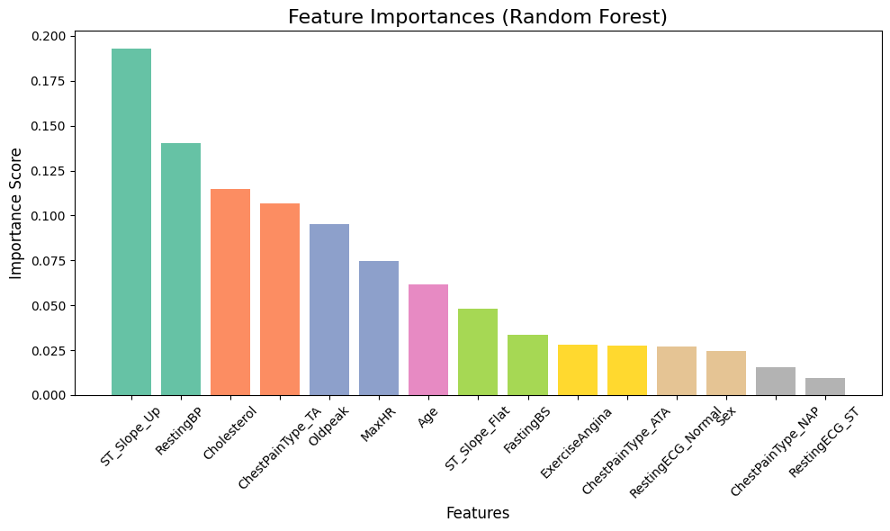

```python
import numpy as np
import matplotlib.pyplot as plt

# Extract feature importances from tuned Random Forest
importances = best_rf.feature_importances_
feature_names = X.columns

# Sort and select top 5
sorted_idx = np.argsort(importances)[::-1]
top_idx = sorted_idx[0:]

top_features = feature_names[top_idx]
top_importances = importances[top_idx]

# Create unique colors for the bars
colors = plt.cm.Set2(np.linspace(0, 1, len(top_features)))

# Plot
plt.figure(figsize=(10, 6))
plt.bar(top_features, top_importances, color=colors)
plt.title("Feature Importances (Random Forest)", fontsize=16)
plt.xlabel("Features", fontsize=12)
plt.ylabel("Importance Score", fontsize=12)
plt.xticks(rotation=45)
plt.tight_layout()
plt.show()
```

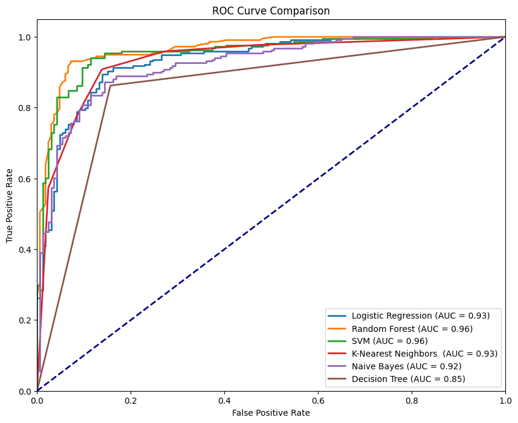

```
Logistic Regression: AUC-ROC = 0.93
Random Forest: AUC-ROC = 0.96
SVM: AUC-ROC = 0.96
K-Nearest Neighbors : AUC-ROC = 0.93
Naive Bayes: AUC-ROC = 0.92
Decision Tree: AUC-ROC = 0.85
```

```python
# from sklearn.ensemble import RandomForestClassifier
# from sklearn.neighbors import KNeighborsClassifier
# from sklearn.svm import SVC

#Define the model
models = {
    'Logistic Regression' : LogisticRegression(),
    'Random Forest' : RandomForestClassifier(),
    'SVM' : SVC(probability=True),
    'K-Nearest Neighbors ': KNeighborsClassifier(),
    'Naive Bayes' : GaussianNB(),
    'Decision Tree' : DecisionTreeClassifier(),

}

# Initialize a dictionary to store AUC - ROC scores
roc_auc_scores = {}

#plot the ROC curve
plt.figure(figsize=(10,8))

for name , model in models.items():
    # train model
    model.fit(X_train , y_train)

    #predict the probabities
    y_probs = model.predict_proba(X_test)[:,1]

    # Calculate the AUC - ROC Score
    roc_auc = roc_auc_score(y_test, y_probs)
    roc_auc_scores[name] = roc_auc

    # Compute ROC Curve
    fpr , tpr , _ =  roc_curve(y_test, y_probs)

    # Plot ROC curve
    plt.plot(fpr, tpr, lw=2, label=f'{name} (AUC = {roc_auc:.2f})')


# Plot the diagonal 50% line
plt.plot([0, 1], [0, 1], color='navy', lw=2, linestyle='--')

# Customize the plot
plt.xlim([0.0, 1.0])
plt.ylim([0.0, 1.05])
plt.xlabel('False Positive Rate')
plt.ylabel('True Positive Rate')
plt.title('ROC Curve Comparison')
plt.legend(loc="lower right")
plt.show()

# Print the AUC - ROC scores for each model
for name, score in roc_auc_scores.items():
    print(f'{name}: AUC-ROC = {score:.2f}')
```